# Betke-Briana-ADA-Homework-2

Briana Betke

3/9/2020

## Homework 2

### Challenge 1: Enjoying the horror of for loops with movies!

#### Step 1: Read in the necessary packages and data

```r
library(tidyverse)
library(cowplot)
theme_set(theme_cowplot()) # b/c no grids in my graphs!!
f <- "https://raw.githubusercontent.com/difiore/ADA-datasets/master/IMDB-movies.csv"
d <- read_csv(f, col_names = TRUE)
```

#### Step 2. Filter out movies b/w 1920-1979 and runtime of < 240 minutes. Then create a variable called decades for each decade of movies.

I used a poo load of ifelse statements, jk just 5 of them. Just an excuse to say poo.

```r
s <- filter(d, runtimeMinutes < 240 & startYear %in% 1920:1979) %>%
  mutate(decade = if_else(startYear %in% 1920:1929,"20s",
                         if_else(startYear %in% 1930:1939,"30s",
                                 if_else(startYear %in% 1940:1949,"40s",
                                         if_else(startYear %in% 1950:1959,"50s",
                                                if_else(startYear %in% 1960:1969,"60s","70s"))))))
```

#### Step 3. Graph runtimes by decade with *GGPPLOOOOTT!!!!*

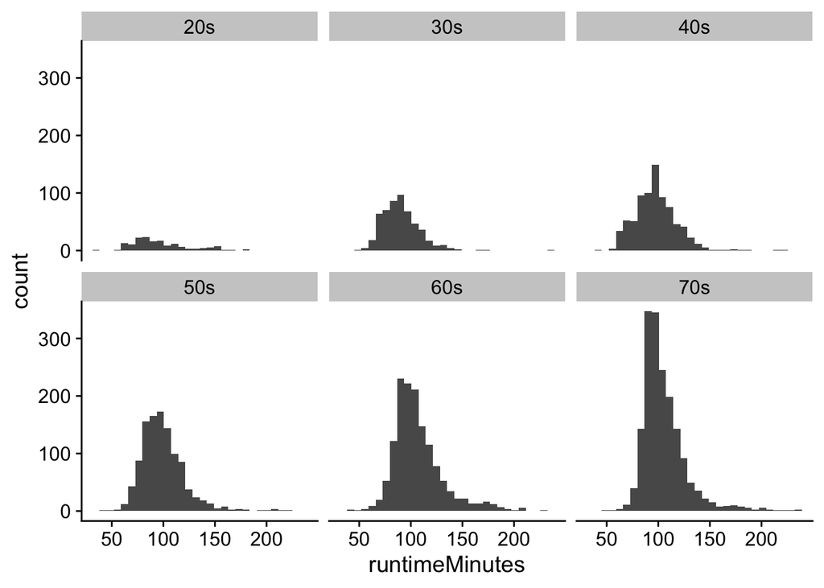

```r
# create histograms of runtimes by decade.
p <- ggplot(s,aes(x=runtimeMinutes))+
  geom_histogram()+
  facet_wrap(~decade)
p
```

#### Step 4. Calculate mean and standard deviations by decade and save to results.

```r
results <- group_by(s, decade)%>%
  summarise(n_cases = n(),
            avg = mean(runtimeMinutes, na.rm = TRUE),
            popSD = sqrt(sum((runtimeMinutes - mean(runtimeMinutes))^2) / length(runtimeMinutes)))
results
```

```
## # A tibble: 6 x 4
##   decade n_cases   avg popSD
##   <chr>    <int> <dbl> <dbl>
## 1 20s        156  96.0  27.4
## 2 30s        536  90.2  18.6
## 3 40s        791  97.3  20.6
## 4 50s       1094  99.6  21.5
## 5 60s       1417 107.   24.3
## 6 70s       1747 105.   21.4
```

#### Step 5. Single sample of 100 movies. Calcualte the mean, sd, and se.

```r
Sample_decades <- group_by(s, decade) %>% sample_n(100)

outcome <- group_by(Sample_decades, decade) %>%
  summarize(
    avg = mean(runtimeMinutes, na.rm = TRUE),
    SD = sd(runtimeMinutes, na.rm = TRUE),
    se = SD/sqrt(100)
  )
outcome
```

```
## # A tibble: 6 x 4
##   decade   avg    SD    se
##   <chr>  <dbl> <dbl> <dbl>
## 1 20s     97.8  27.7  2.77
## 2 30s     90.1  18.3  1.83
## 3 40s     97.3  19.0  1.90
## 4 50s    101.   23.7  2.37
## 5 60s    107.   20.4  2.04
## 6 70s    106.   22.7  2.27
```

Compare to the population se for each decade. Not too far off!

```r
results
```

```
## # A tibble: 6 x 4
##   decade n_cases   avg popSD
##   <chr>    <int> <dbl> <dbl>
## 1 20s        156  96.0  27.4
## 2 30s        536  90.2  18.6
## 3 40s        791  97.3  20.6
## 4 50s       1094  99.6  21.5
## 5 60s       1417 107.   24.3
## 6 70s       1747 105.   21.4
```

```r
(results$popSD)/sqrt(100)
```

```
## [1] 2.743508 1.864468 2.055356 2.154956 2.430888 2.135976
```

#### Step 6. 10000 samples of size 100.

```r
# 10,000 samples of size 100 for each decade?
# probably the long way to do it but subset the decades and sample each one w/ a for loop?
library(mosaic) # my for loop does not run unless I read in the mosaic package.

just20s <- filter(s, decade == "20s")
just30s <- filter(s, decade == "30s")
just40s <- filter(s, decade == "40s")
just50s <- filter(s, decade == "50s")
just60s <- filter(s, decade == "60s")
just70s <- filter(s, decade == "70s")

k <- 10000 # number of samples
n <- 100  # size of each sample

samp20 <- list(length = k)
samp30 <- list(length = k)
samp40 <- list(length = k)
samp50 <- list(length = k)
samp60 <- list(length = k)
samp70 <- list(length = k)# create a dummy variable to hold each sample
for (i in 1:k) {
  samp20[[i]] <- sample(just20s, size = n, replace = FALSE)
  samp30[[i]] <- sample(just30s, size = n, replace = FALSE)
  samp40[[i]] <- sample(just40s, size = n, replace = FALSE)
  samp50[[i]] <- sample(just50s, size = n, replace = FALSE)
  samp60[[i]] <- sample(just60s, size = n, replace = FALSE)
  samp70[[i]] <- sample(just70s, size = n, replace = FALSE)
}
# I could have done $runtime minute notation, but I didn't lol
```

Then calculate the means of each sample

```r
# set up empty vectors to store the means for each decade.
m20 <- vector(length = k)
m30 <- vector(length = k)
m40 <- vector(length = k)
m50 <- vector(length = k)
m60 <- vector(length = k)
m70 <- vector(length = k)

for (i in 1:k) {
  m20[[i]] <- mean(samp20[[i]][["runtimeMinutes"]])
  m30[[i]] <- mean(samp30[[i]][["runtimeMinutes"]])
  m40[[i]] <- mean(samp40[[i]][["runtimeMinutes"]])
  m50[[i]] <- mean(samp50[[i]][["runtimeMinutes"]])
  m60[[i]] <- mean(samp60[[i]][["runtimeMinutes"]])
  m70[[i]] <- mean(samp70[[i]][["runtimeMinutes"]])
}

head(m20)
```

```
## [1] 97.17 95.21 98.56 94.99 93.60 96.31
```

```r
head(m30)
```

```
## [1] 88.53 91.77 93.50 87.96 90.70 88.03
```

```r
head(m40)
```

```
## [1] 95.89 95.29 97.38 95.88 97.80 96.72
```

```r
head(m50)
```

```
## [1]  99.16  96.42  99.30  98.52 101.82 100.09
```

```r
head(m60)
```

```
## [1] 107.66 105.02 109.02 106.57 107.28 106.22
```

```r
head(m60)
```

```
## [1] 107.66 105.02 109.02 106.57 107.28 106.22
```

```r
head(m70)
```

```
## [1] 109.19 103.20 104.04 107.02 104.63 108.73
```

Then the standard deviations

```r
# Calculating sd
sample_sd20 <- vector(length = k)
sample_sd30 <- vector(length = k)
sample_sd40 <- vector(length = k)
sample_sd50 <- vector(length = k)
sample_sd60 <- vector(length = k)
sample_sd70 <- vector(length = k)
# create a dummy variable to hold the SD of each sample
for (i in 1:k) {
  sample_sd20[[i]] <- sd(samp20[[i]][["runtimeMinutes"]]) # a vector of SDs for each sample
  sample_sd30[[i]] <- sd(samp30[[i]][["runtimeMinutes"]])
  sample_sd40[[i]] <- sd(samp40[[i]][["runtimeMinutes"]])
  sample_sd50[[i]] <- sd(samp50[[i]][["runtimeMinutes"]])
  sample_sd60[[i]] <- sd(samp60[[i]][["runtimeMinutes"]])
  sample_sd70[[i]] <- sd(samp70[[i]][["runtimeMinutes"]])
}

head(sample_sd20)
```

```
## [1] 28.14323 26.78432 30.07510 27.02954 27.71864 29.47099
```

```r
head(sample_sd30)
```

```
## [1] 16.40796 17.51989 24.96725 18.04367 18.71557 15.98450
```

```r
head(sample_sd40)
```

```
## [1] 19.19380 23.04028 21.79138 17.17602 24.70758 22.48774
```

```r
head(sample_sd50)
```

```
## [1] 20.08050 16.98554 19.38316 24.64802 25.23961 24.38790
```

```r
head(sample_sd60)
```

```
## [1] 20.61980 24.16023 26.64620 22.28885 22.88358 24.06119
```

```r
head(sample_sd70)
```

```
## [1] 22.40387 18.89364 20.33006 20.08617 19.04575 25.09934
```

I was not sure if the last statment means that we should look at the sd of the sampling distribution to compare to the population se *sssoooooo I did it anyway….*

```r
# Not clear if we should calculate the sd for the distirbution to compare to pop se but
# its right here just incase....
sd(m20)
```

```
## [1] 1.655266
```

```r
sd(m30)
```

```
## [1] 1.692757
```

```r
sd(m40)
```

```
## [1] 1.917355
```

```r
sd(m50)
```

```
## [1] 2.037273
```

```r
sd(m60)
```

```
## [1] 2.370697
```

```r
sd(m70)
```

```
## [1] 2.067732
```

### Challenge 2: Wish I could think of a poisson pun…

#### Step 1. Calculate the probability that she will hear 13 or fewer calls during any given session.

```r
ppois(13, lambda = 18)
```

```
## [1] 0.1425978
```

#### Step 2. Calculate the probability that she will hear no calls in a session.

```r
dpois(0, lambda = 18)
```

```
## [1] 1.522998e-08
```

#### Step 3. Calculate the probability that she will hear exactly 7 calls in a session.

```r
dpois(7, lambda = 18)
```

```
## [1] 0.00185002
```

#### Step 4. Calculate the probability that she will hear more than 20 calls in a session.

```r
ppois(20, lambda = 18, lower.tail = FALSE)
```

```
## [1] 0.2692798
```

#### Step 5. Plot the relevant Poisson mass function over the values in range 0 ≤ x ≤ 40.

Don’t forget to read in the mosaic package for the plotDist function! But I read mosaic in challege 1 so I did not detach it…

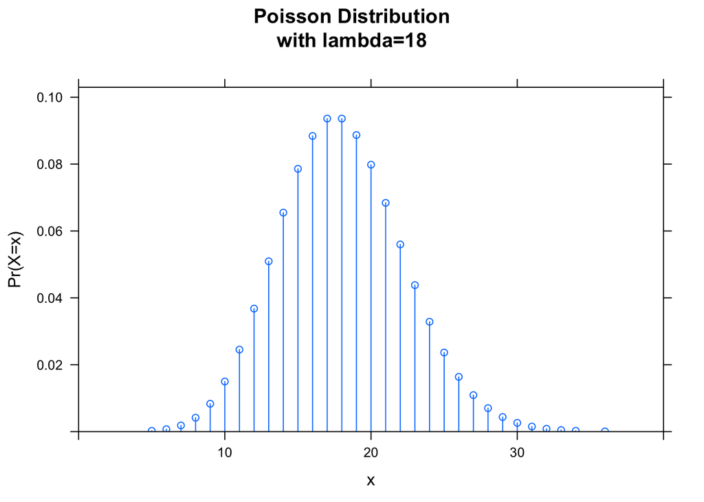

```r
# plot probability mass function
# library(mosaic)
l <- 18
pmf_poisson <-
  plotDist(
    "pois",
    lambda = l,
    xlim = c(0,40),
    main = paste0("Poisson Distribution\nwith lambda=", l),
    xlab = "x",
    ylab = "Pr(X=x)"
  )
pmf_poisson
```

#### Step 6. Simulate 520 results from this distribution and plot using the historam() from mosaic.

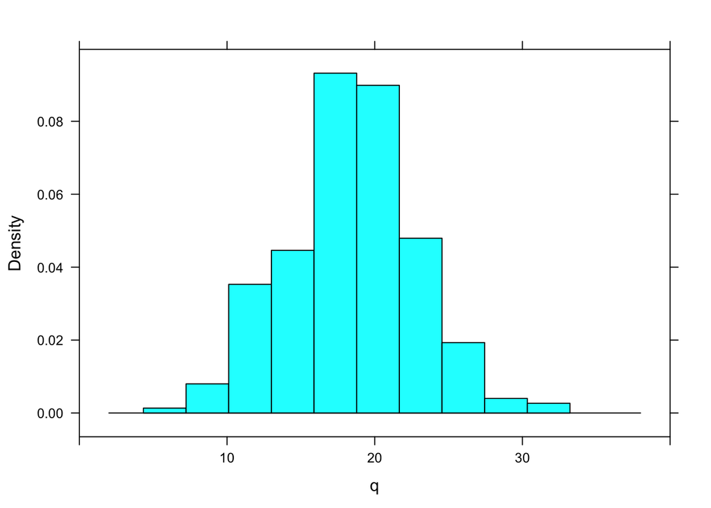

```r
q <- rpois(520, lambda = 18)

histogram(q,  xlim = c(0,40))
```

The shape between the simulation and the probability mass funtion look similar.

### Challenge 3: ZOMBIES…no time for clever challenge names!

#### Step 1. Read in the zombie data

```r
# get that zombie data
f <- "https://raw.githubusercontent.com/difiore/ADA-datasets/master/zombies.csv"
d <- read_csv(f, col_names = TRUE)
```

#### Step 2. Calculating population mean and sd for each quatitative random variable

```r
pop_var <- function(x) {
  sum((x - mean(x))^2) / (length(x))
}

pop_sd <- function(x) {
  sqrt(pop_var(x))
}

results2 <- summarise(d,
  avgH = mean(height, na.rm = TRUE),
  avgW = mean(weight, na.rm = TRUE),
  avgZ = mean(zombies_killed, na.rm = TRUE),
  avgE = mean(years_of_education,na.rm = TRUE),
  avgA = mean(age,na.rm = TRUE),
  sdH = pop_sd(height),
  sdW = pop_sd(weight),
  sdZ = pop_sd(zombies_killed),
  sdE = pop_sd(years_of_education),
  sdA = pop_sd(age)
)
results2
```

```
## # A tibble: 1 x 10
##    avgH  avgW  avgZ  avgE  avgA   sdH   sdW   sdZ   sdE   sdA
##   <dbl> <dbl> <dbl> <dbl> <dbl> <dbl> <dbl> <dbl> <dbl> <dbl>
## 1  67.6  144.  2.99  3.00  20.0  4.31  18.4  1.75  1.68  2.96
```

#### Step 3. Create graphs of weight and height in realtion to age.

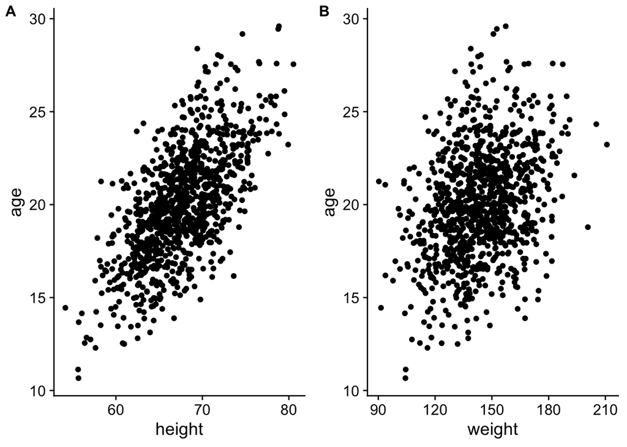

```r
# scatter plot of weight and height
# SET UP THE NEATO GRAPHS
p1 <- ggplot(data = d, aes(
  x = height,
  y = age,)) +
  geom_point(na.rm = TRUE)

p2 <- ggplot(data = d, aes(
  x = weight,
  y = age,)) +
  geom_point(na.rm = TRUE)

plot_grid(p1, p2, labels = c("A", "B"), label_size = 12, nrow = 1)
```

#### Step 4. Make histograms and Q-Q plots to check whether the quantitative variables seem to be drawn from a normal distribution.

Histograms, shmistograms

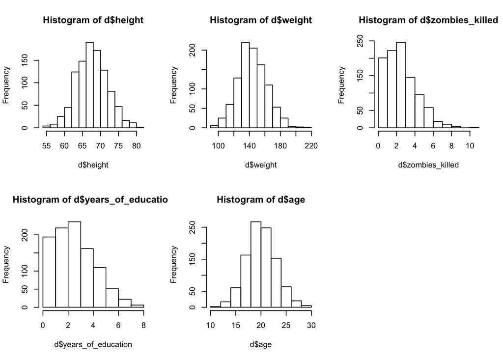

```r
par(mfrow=c(2,3))
hist(d$height)
hist(d$weight)
hist(d$zombies_killed)
hist(d$years_of_education)
hist(d$age)
par(mfrow=c(1,1)) # do this to reset b/c par ruins everything
```

The histograms of years of education and zombies killed look like they are not drawn from a normal distribution. Both appear to be right skewed.

QQ plots, with lots o dots

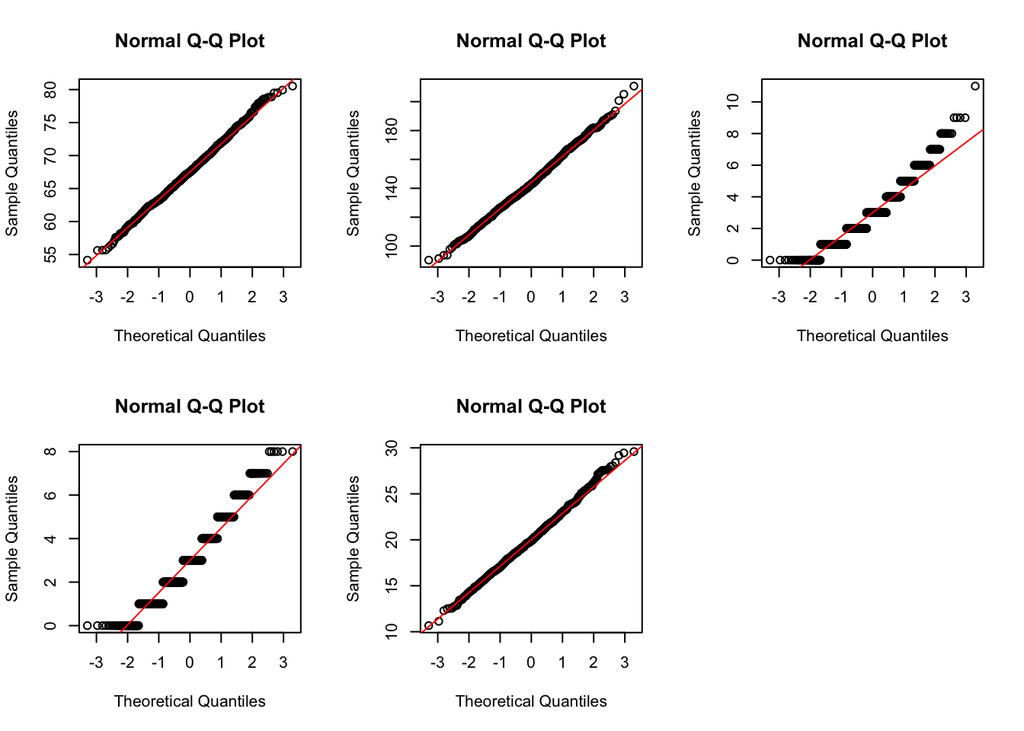

```r
par(mfrow=c(2,3))
qqnorm(d$height)
qqline(d$height, col = "red")

qqnorm(d$weight)
qqline(d$weight, col = "red")

qqnorm(d$zombies_killed)
qqline(d$zombies_killed, col = "red")

qqnorm(d$years_of_education)
qqline(d$years_of_education, col = "red")

qqnorm(d$age)
qqline(d$age, col = "red")
par(mfrow=c(1,1))
```

#### Step 5. Single sample of distribution of size 30

```r
(Zombie30 <- sample_n(d, 30))
```

```
## # A tibble: 30 x 10
##       id first_name last_name gender height weight zombies_killed
##    <dbl> <chr>      <chr>     <chr>   <dbl>  <dbl>          <dbl>
##  1   648 Jerry      Young     Male     65.9   141.              1
##  2   789 George     Willis    Male     74.5   167.              3
##  3   310 Steve      Hill      Male     71.0   155.              4
##  4   497 Sara       Harper    Female   62.6   135.              3
##  5   671 Lisa       Harper    Female   65.8   135.              2
##  6   284 Frances    Cook      Female   58.1   111.              3
##  7   319 Amy        Matthews  Female   64.5   130.              0
##  8    15 Donald     Murray    Male     65.7   121.              4
##  9   730 Emily      Mendoza   Female   65.5   134.              4
## 10   620 Sarah      Mills     Female   62.5   117.              3
## # … with 20 more rows, and 3 more variables: years_of_education <dbl>,
## #   major <chr>, age <dbl>
```

#### Step 6. Calculate the mean, standard deviation,standard error and CI of each quantitative variable.

##### Height

```r
# calculations for height
(meanH <- mean(Zombie30$height))
```

```
## [1] 66.507
```

```r
(SD.h <- sd(Zombie30$height))
```

```
## [1] 4.561642
```

```r
(seH <- sd(Zombie30$height) / sqrt(length(Zombie30$height)))
```

```
## [1] 0.8328381
```

```r
(ci_normH <- meanH + c(-1, 1) * qnorm(1 - 0.05 / 2) * seH)
```

```
## [1] 64.87466 68.13933
```

##### Weight

```r
# calcualtions for weight
(meanW <- mean(Zombie30$weight))
```

```
## [1] 138.2544
```

```r
(SD.W <- sd(Zombie30$weight))
```

```
## [1] 18.33599
```

```r
(seW <- sd(Zombie30$weight) / sqrt(length(Zombie30$weight)))
```

```
## [1] 3.347678
```

```r
(ci_normW <- meanW + c(-1, 1) * qnorm(1 - 0.05 / 2) * seW)
```

```
## [1] 131.6931 144.8157
```

##### Zombies Killed

```r
# Calcualtions for zombies killed
(meanK <- mean(Zombie30$zombies_killed))
```

```
## [1] 2.8
```

```r
(SD.K <- sd(Zombie30$zombies_killed))
```

```
## [1] 1.423933
```

```r
(seK <- sd(Zombie30$zombies_killed) / sqrt(length(Zombie30$zombies_killed)))
```

```
## [1] 0.2599735
```

```r
(ci_normW <- meanK + c(-1, 1) * qnorm(1 - 0.05 / 2) * seK)
```

```
## [1] 2.290461 3.309539
```

##### Years of Education

```r
# Calculations for years of education
(meanE <- mean(Zombie30$years_of_education))
```

```
## [1] 3.1
```

```r
(SD.E <- sd(Zombie30$years_of_education))
```

```
## [1] 1.844844
```

```r
(seE <- sd(Zombie30$years_of_education) / sqrt(length(Zombie30$years_of_education)))
```

```
## [1] 0.3368208
```

```r
(ci_normE <- meanE + c(-1, 1) * qnorm(1 - 0.05 / 2) * seE)
```

```
## [1] 2.439843 3.760157
```

##### Age

```r
# Calculations for age
(meanA <- mean(Zombie30$age))
```

```
## [1] 19.14116
```

```r
(SD.A <- sd(Zombie30$years_of_education))
```

```
## [1] 1.844844
```

```r
(seA <- sd(Zombie30$years_of_education) / sqrt(length(Zombie30$years_of_education)))
```

```
## [1] 0.3368208
```

```r
(ci_normA <- meanA + c(-1, 1) * qnorm(1 - 0.05 / 2) * seA)
```

```
## [1] 18.48101 19.80132
```

#### Step 7. # 99 samples of size 30

```r
k <- 99 # number of samples
n <- 30 # size of each sample
s <- list(length = k) # create a dummy variable to hold each sample
for (i in 1:k) {
  s[[i]] <- sample(d, size = n, replace = FALSE)
}
head(s)
```

```
## $length
## # A tibble: 30 x 11
##       id first_name last_name gender height weight zombies_killed
##    <dbl> <chr>      <chr>     <chr>   <dbl>  <dbl>          <dbl>
##  1   642 Joyce      Kennedy   Female   69.8  149.               1
##  2   169 Rose       Mccoy     Female   70.3  144.               2
##  3   511 Ann        Rivera    Female   57.6   97.7              4
##  4   304 Robert     Parker    Male     73.6  161.               3
##  5   738 Kathy      Jenkins   Female   64.7  134.               4
##  6   489 Patricia   Peters    Female   58.5   93.8              6
##  7   131 Sandra     Myers     Female   70.1  158.               2
##  8   402 Phyllis    Carr      Female   71.0  153.               6
##  9   435 Thomas     Phillips  Male     80.5  187.               3
## 10   295 Adam       Perez     Male     66.4  143.               3
## # … with 20 more rows, and 4 more variables: years_of_education <dbl>,
## #   major <chr>, age <dbl>, orig.id <chr>
##
## [[2]]
## # A tibble: 30 x 11
##       id first_name last_name gender height weight zombies_killed
##    <dbl> <chr>      <chr>     <chr>   <dbl>  <dbl>          <dbl>
##  1   689 Irene      Sims      Female   65.8   130.              7
##  2    97 Ryan       Davis     Male     65.1   133.              2
##  3   309 Tammy      Porter    Female   64.9   124.              2
##  4   756 Amanda     Rogers    Female   60.7   124.              2
##  5   111 Wanda      Russell   Female   69.9   134.              3
##  6   897 Janet      Meyer     Female   66.8   167.              2
##  7   541 Roger      Gray      Male     63.2   157.              1
##  8   597 Linda      Patterson Female   63.1   106.              2
##  9   688 Roy        Alexander Male     74.5   156.              3
## 10   518 Jacqueline Cole      Female   67.3   142.              6
## # … with 20 more rows, and 4 more variables: years_of_education <dbl>,
## #   major <chr>, age <dbl>, orig.id <chr>
##
## [[3]]
## # A tibble: 30 x 11
##       id first_name last_name gender height weight zombies_killed
##    <dbl> <chr>      <chr>     <chr>   <dbl>  <dbl>          <dbl>
##  1   176 Amanda     Burton    Female   63.6   139.              4
##  2   588 Wayne      Howell    Male     65.7   127.              2
```

[output cut: 46 more lines]

```
## # A tibble: 30 x 11
##       id first_name last_name gender height weight zombies_killed
##    <dbl> <chr>      <chr>     <chr>   <dbl>  <dbl>          <dbl>
##  1   609 Steve      Flores    Male     73.9   154.              1
##  2   282 Joe        Burton    Male     68.6   149.              3
##  3   152 Anne       Hernandez Female   62.6   123.              0
##  4   766 Carlos     Hart      Male     69.7   162.              2
##  5   353 Teresa     King      Female   72.1   169.              1
##  6    43 Douglas    Smith     Male     74.2   201.              7
##  7    85 Anthony    Burton    Male     69.1   163.              3
##  8   558 James      Arnold    Male     66.8   138.              3
##  9   929 Raymond    Ferguson  Male     64.2   119.              6
## 10   714 Edward     Day       Male     66.3   159.              3
## # … with 20 more rows, and 4 more variables: years_of_education <dbl>,
## #   major <chr>, age <dbl>, orig.id <chr>
```

#### Step 8. Calculate the means and standard deviations of the samples.

Starting with the means.

```r
# Calculating means
mH <- vector(length = k)
mW <- vector(length = k)
mK <- vector(length = k)
mE <- vector(length = k)
mA <- vector(length = k)
for (i in 1:k) {
  mH[[i]] <- mean(s[[i]][["height"]])
  mW[[i]] <- mean(s[[i]][["weight"]])
  mK[[i]] <- mean(s[[i]][["zombies_killed"]])
  mE[[i]] <- mean(s[[i]][["years_of_education"]])
  mA[[i]] <- mean(s[[i]][["age"]])
}
head(mH)
```

```
## [1] 66.71020 66.86178 67.72741 67.39689 67.98742 68.04116
```

```r
head(mW)
```

```
## [1] 139.8242 140.0569 141.4711 142.9512 145.8716 147.2950
```

```r
head(mK)
```

```
## [1] 2.733333 2.900000 3.133333 3.133333 3.000000 3.033333
```

```r
head(mE)
```

```
## [1] 2.900000 3.000000 3.333333 2.833333 2.766667 3.433333
```

```r
head(mA)
```

```
## [1] 19.99060 20.52188 20.04513 20.50324 20.36859 20.02236
```

Calculate the standard devaiations.

```r
# Calculating sd
sample_sdH <- vector(length = k)
sample_sdW <- vector(length = k)
sample_sdK <- vector(length = k)
sample_sdE <- vector(length = k)
sample_sdA <- vector(length = k)
# create a dummy variable to hold the SD of each sample
for (i in 1:k) {
  sample_sdH[[i]] <- sd(s[[i]][["height"]]) # a vector of SDs for each sample
  sample_sdW[[i]] <- sd(s[[i]][["weight"]])
  sample_sdK[[i]] <- sd(s[[i]][["zombies_killed"]])
  sample_sdE[[i]] <- sd(s[[i]][["years_of_education"]])
  sample_sdA[[i]] <- sd(s[[i]][["age"]])
}

head(sample_sdH)
```

```
## [1] 5.244155 3.964443 4.978654 4.714339 4.150032 4.364152
```

```r
head(sample_sdW)
```

```
## [1] 23.26789 17.93685 20.47557 23.26146 19.68213 21.60467
```

```r
head(sample_sdK)
```

```
## [1] 1.574218 1.688705 1.634400 1.716720 1.364576 1.956128
```

```r
head(sample_sdE)
```

```
## [1] 1.826057 1.875431 1.899788 1.533158 1.813424 1.887953
```

```r
head(sample_sdA)
```

```
## [1] 3.643701 2.843318 3.076564 3.533526 2.628048 2.813623
```

#### Step 9. Comparison of SEs to population.

##### Height

```r
# For height
sd(mH) # SD of means
```

```
## [1] 0.7601619
```

```r
sample_seH <- sample_sdH / sqrt(n)
mean(sample_seH) # means of se
```

```
## [1] 0.7699018
```

```r
(pop_se <- results2$sdH / (sqrt(n))) # se of population
```

```
## [1] 0.7865241
```

##### Weight

```r
# For weight
sd(mW)
```

```
## [1] 3.39965
```

```r
sample_seW <- sample_sdW / sqrt(n)
mean(sample_seW)
```

```
## [1] 3.280879
```

```r
(pop_se <- results2$sdW / (sqrt(n)))
```

```
## [1] 3.357878
```

##### Number of zombie kills

```r
# For Number of kills
sd(mK)
```

```
## [1] 0.3044724
```

```r
sample_seK <- sample_sdK / sqrt(n)
mean(sample_seK)
```

```
## [1] 0.3104614
```

```r
(pop_se <- results2$sdZ / (sqrt(n)))
```

```
## [1] 0.3190578
```

##### Years of education

```r
# Years of education
sd(mE)
```

```
## [1] 0.3075018
```

```r
sample_seE <- sample_sdE / sqrt(n)
mean(sample_seE)
```

```
## [1] 0.3085108
```

```r
(pop_se <- results2$sdE / (sqrt(n)))
```

```
## [1] 0.3059403
```

##### Age

```r
# age
sd(mA)
```

```
## [1] 0.5042347
```

```r
sample_seA <- sample_sdA / sqrt(n)
mean(sample_seA)
```

```
## [1] 0.5290648
```

```r
(pop_se <- results2$sdA / (sqrt(n)))
```

```
## [1] 0.5410737
```

#### Step 10. Histograms of distributions.

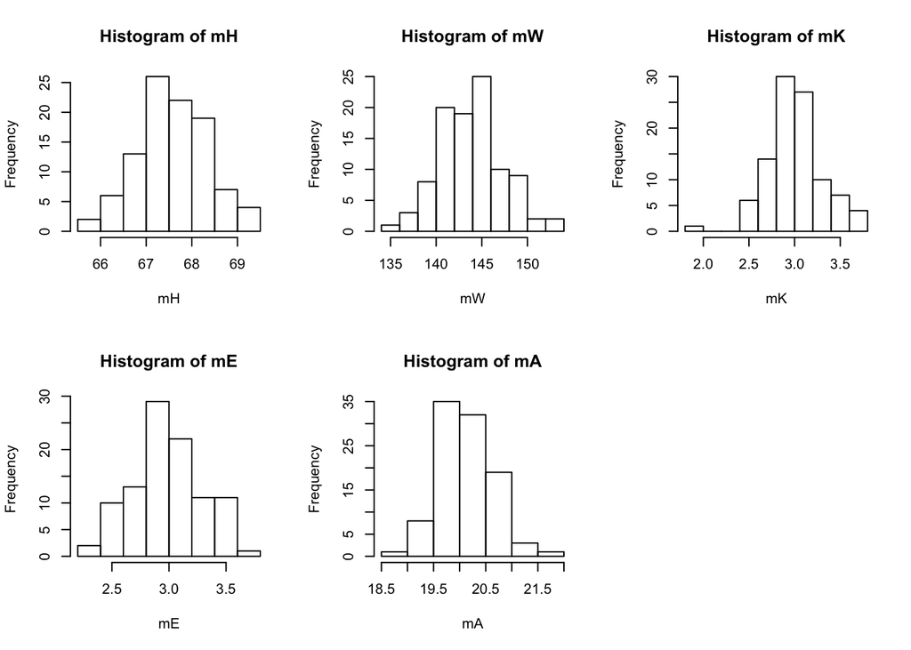

```r
# distributions of sample means
par(mfrow=c(2,3))
hist(mH)
hist(mW)
hist(mK)
hist(mE)
hist(mA)
par(mfrow=c(1,1))
```

The sampling distributions that I said didn’t seem to be drawn from a normal distribution look normal in comparison.